# Juarez, Kathleen -M06-Reflection Essay-Adv Data-Wrangling.qmd

Kathleen Juarez

IBM 6530, Cal Poly Pomona

February 17, 2026

# Essay portion of assignment

## In Step 1, you learned how to design stunning presentation slides with Quarto. What’s your impression of the Revealjs presentation? Describe its capabilities as you learned from the presentations. What are its strengths and weaknesses compared with PPT

## In Step 2, you were asked to create a Revealjs presentation. Provide a link to the presentation you published on the web. Add at least one reproducible chart or table in the presentation. Briefly describe what the presentation is about. What did you learn from the experience of the Revealjs presentation?

# Revealjs is Cool! A Presentation by Kathleen

## Slide 1

This should appear in your custom primary color.

## Competitive Analysis

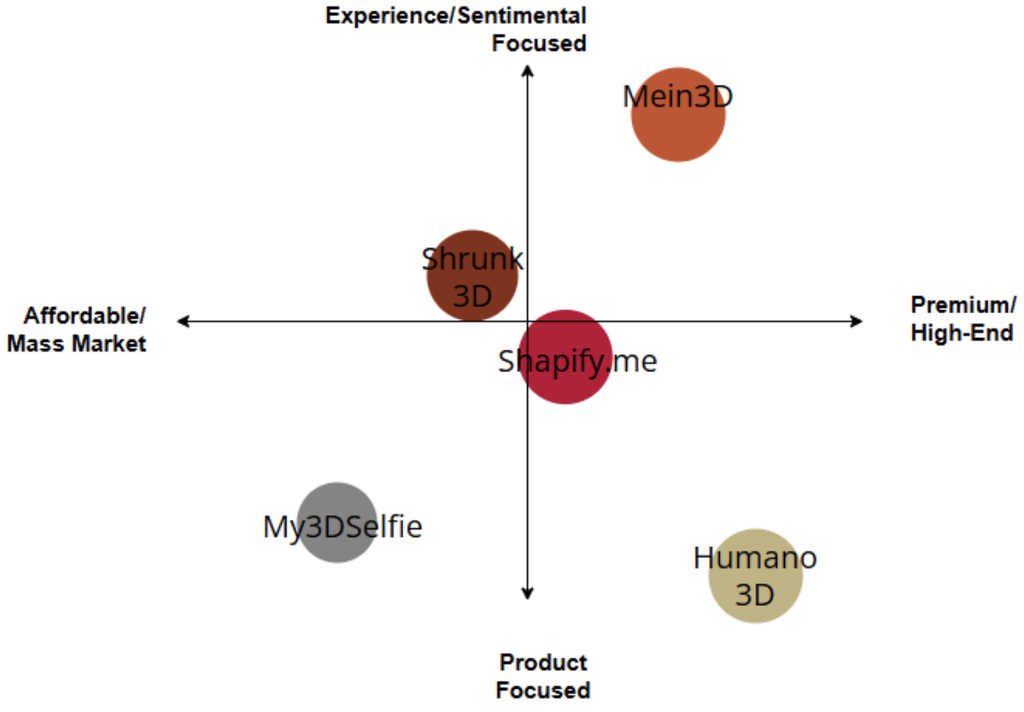

# Slide 3

# Section: Lists & Fragments

## Incremental lists (automatic)

- First point appears
- Then this one
- Then this one

> Because `incremental: true` is set in YAML, lists reveal item-by-item.

## Manual incremental list (only some items)

- This appears immediately (NOT incremental)
- This also appears immediately
- This starts incremental (manual)
- Then this
- Then this

## Fragments (fine-grained control)

Use fragments when you want *non-list* elements to appear stepwise:

This appears first.

This appears second (a paragraph).

A whole block can be a fragment too.

## Content overflow (scroll inside slide)

Sometimes text is too long. You can make a scrollable region:

**Scrollable content area** - Line 1 - Line 2 - Line 3 - Line 4 - Line 5 - Line 6 - Line 7 - Line 8 - Line 9 - Line 10 - Line 11 - Line 12 - Line 13 - Line 14 - Line 15

## Speaker notes

Visible to you (Presenter View), hidden from audience.

## Asides & Footnotes

### Aside (small side note)

### Footnote example

This is an **aside**. It’s useful for secondary info that shouldn’t compete with the main message.

# Section: Theme & Styling

cool cool McGruel

That’s what she said